# Cyclistic Analysis Summary

Cole Espinola

2023-09-13

## Enviroment Setup

```r
library(tidyverse)
```

## Data Loading

The following data is a cleaned, transformed, and merged version of the data from [Divvy Trips Data](https://divvy-tripdata.s3.amazonaws.com/index.html) from May 2023 to July 2023. The data was transformed by adding the ride length of each ride in minutes and the day of the week each ride started with Sunday as 1, Monday as 2, and so on.

```r
trips_05_to_07_2023 <- read_csv("~/Coursera Capstone Project/data/clean_data/clean_new_trips_05_to_07_2023.csv")
```

```
## ──────────────────────────────────────────────────────── Delimiter: "," chr
## (7): ride_id, rideable_type, start_station_name, start_station_id, end_... dbl
## (7): ...1, start_lat, start_lng, end_lat, end_lng, ride_length_min, day... dttm
## (2): started_at, ended_at
```

### Sample of Data

The following is a preview of the column names of the data set:

```r
head(trips_05_to_07_2023)
```

```
## # A tibble: 6 × 16
##    ...1 ride_id          rideable_type started_at          ended_at
##   <dbl> <chr>            <chr>         <dttm>              <dttm>
## 1     1 DDEB93BC2CE9AA77 classic_bike  2023-05-10 16:47:01 2023-05-10 16:59:52
## 2     2 C07B70172FC92F59 classic_bike  2023-05-09 18:30:34 2023-05-09 18:39:28
## 3     3 2BA66385DF8F815A classic_bike  2023-05-30 15:01:21 2023-05-30 15:17:00
## 4     4 31EFCCB05F12D8EF docked_bike   2023-05-09 14:13:40 2023-05-09 14:47:20
## 5     5 71DFF834E1D3CE0B classic_bike  2023-05-06 16:47:22 2023-05-06 16:52:13
## 6     6 2117485899B4CEA4 classic_bike  2023-05-15 12:47:26 2023-05-15 13:00:05
## # ℹ 11 more variables: start_station_name <chr>, start_station_id <chr>,
## #   end_station_name <chr>, end_station_id <chr>, start_lat <dbl>,
## #   start_lng <dbl>, end_lat <dbl>, end_lng <dbl>, member_casual <chr>,
## #   ride_length_min <dbl>, day_of_week <dbl>
```

We will also now take a closer look at all of the column names of the data:

```r
colnames(trips_05_to_07_2023)
```

```
##  [1] "...1"               "ride_id"            "rideable_type"
##  [4] "started_at"         "ended_at"           "start_station_name"
##  [7] "start_station_id"   "end_station_name"   "end_station_id"
## [10] "start_lat"          "start_lng"          "end_lat"
## [13] "end_lng"            "member_casual"      "ride_length_min"
## [16] "day_of_week"
```

## Interrogating the Data

We will now begin examining our data by asking the following questions:

### Question 1: what day do annual members and casual riders use cyclistic bikes the most?

```r
most_popular_day <- trips_05_to_07_2023 %>% group_by(day_of_week) %>%
  summarise(member = sum(member_casual == "member"), casual = sum(member_casual == "casual"))
most_popular_day
```

```
## # A tibble: 7 × 3
##   day_of_week member casual
##         <dbl>  <int>  <int>
## 1           1 105789 108734
## 2           2 136355  82451
## 3           3 138671  72946
## 4           4 139846  68352
## 5           5 149100  80558
## 6           6 134717  93803
## 7           7 125338 135358
```

Corresponding visualizations:

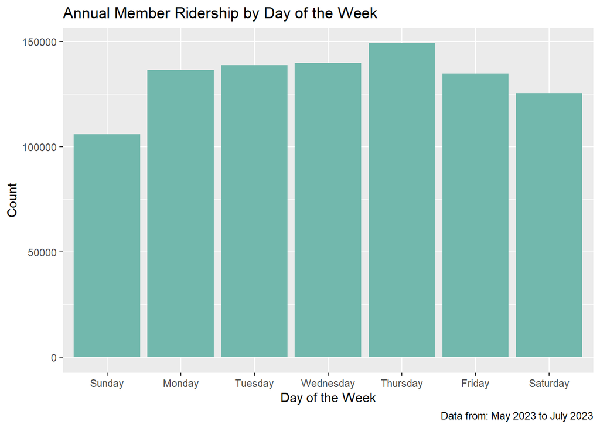

```r
week_names <- c("Sunday", "Monday", "Tuesday", "Wednesday", "Thursday", "Friday", "Saturday")
ggplot(data = most_popular_day, aes(x = factor(day_of_week), y = member)) + geom_bar(stat = "identity", fill='#72B8AD') +
  labs(title = "Annual Member Ridership by Day of the Week", x = "Day of the Week", y = "Count",
       caption = "Data from: May 2023 to July 2023") +
  scale_x_discrete(labels = week_names)
```

Clearly, Thursday was the day of the week that annual Cyclistic members rode the most with the weekdays in particular being more popular than the weekends.

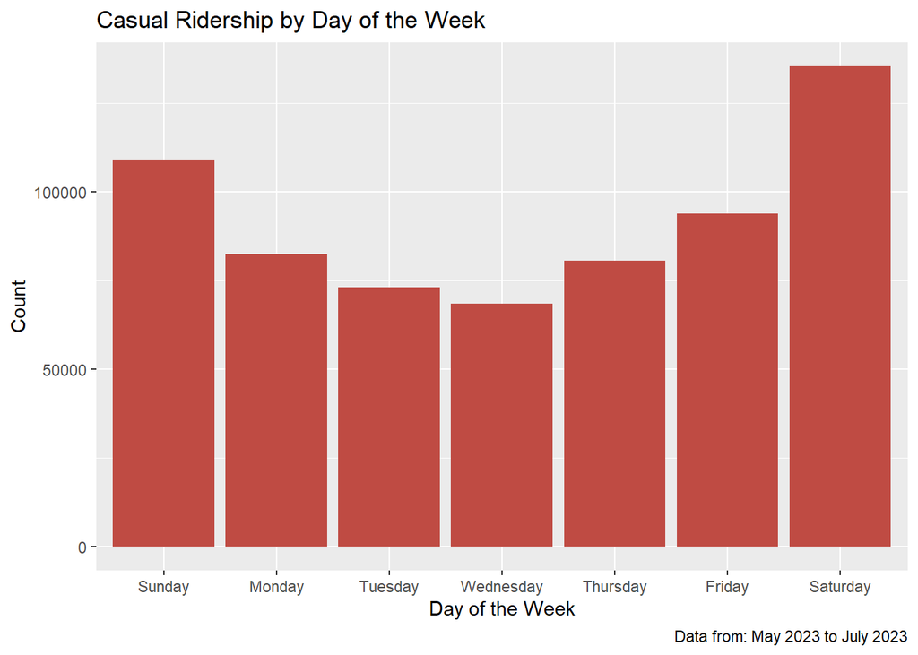

```r
week_names <- c("Sunday", "Monday", "Tuesday", "Wednesday", "Thursday", "Friday", "Saturday")
ggplot(data = most_popular_day, aes(x = factor(day_of_week), y = casual)) + geom_bar(stat = "identity", fill='#BF4B43') +
  labs(title = "Casual Ridership by Day of the Week", x = "Day of the Week", y = "Count",
       caption = "Data from: May 2023 to July 2023") +
  scale_x_discrete(labels = week_names) + scale_y_continuous(labels = function(x) format(x, scientific = FALSE))
```

Meanwhile, Saturday was the day of the week that casual riders rode the most with weekday being far less popular than weekends.

### Question 2: how many of the rides in past three months are from members and how many from casual riders?

```r
mem_cas_ride_count <- trips_05_to_07_2023 %>% group_by(member_casual) %>%
summarise(values = n())
mem_cas_ride_count
```

```
## # A tibble: 2 × 2
##   member_casual values
##   <chr>          <int>
## 1 casual        642202
## 2 member        929816
```

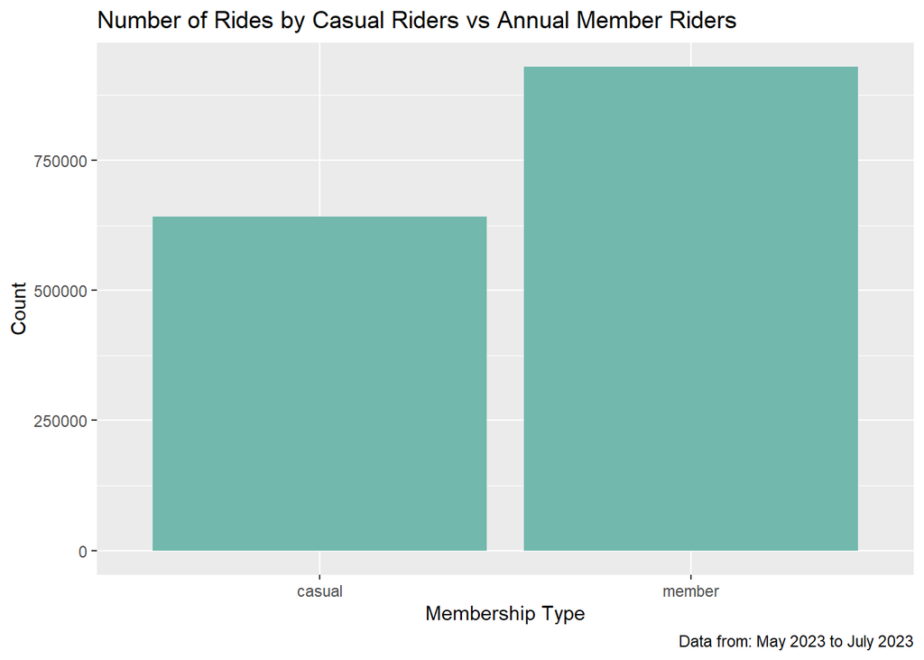

```r
ggplot(data = trips_05_to_07_2023, aes(x = member_casual)) + geom_bar(fill='#72B8AD') +
  labs(title = "Number of Rides by Casual Riders vs Annual Member Riders", x = "Membership Type", y = "Count",
       caption = "Data from: May 2023 to July 2023")
```

### Question 3: what is the most popular start staion for annual members vs casual riders?

As sorted by most popular among members (descending):

```r
popular_member_start_station <- trips_05_to_07_2023 %>% group_by(start_station_name) %>%
  summarise(member = sum(member_casual == "member")) %>%
  arrange(desc(member))
popular_member_start_station
```

```
## # A tibble: 1,364 × 2
##    start_station_name                 member
##    <chr>                               <int>
##  1 Kingsbury St & Kinzie St             7634
##  2 Clark St & Elm St                    7531
##  3 Streeter Dr & Grand Ave              7181
##  4 Clinton St & Washington Blvd         7010
##  5 DuSable Lake Shore Dr & North Blvd   6852
##  6 Wells St & Concord Ln                6706
##  7 Wells St & Elm St                    6034
##  8 Michigan Ave & Oak St                6002
##  9 Theater on the Lake                  5981
## 10 Broadway & Barry Ave                 5649
## # ℹ 1,354 more rows
```

As sorted by most popular among casual riders (descending):

```r
popular_casual_start_station <- trips_05_to_07_2023 %>% group_by(start_station_name) %>%
  summarise(casual = sum(member_casual == "casual")) %>%
  arrange(desc(casual))
popular_casual_start_station
```

```
## # A tibble: 1,364 × 2
##    start_station_name                 casual
##    <chr>                               <int>
##  1 Streeter Dr & Grand Ave             20331
##  2 DuSable Lake Shore Dr & Monroe St   12965
##  3 Michigan Ave & Oak St               10456
##  4 DuSable Lake Shore Dr & North Blvd   9968
##  5 Millennium Park                      8575
##  6 Theater on the Lake                  7762
##  7 Shedd Aquarium                       6891
##  8 Dusable Harbor                       6639
##  9 Montrose Harbor                      5657
## 10 Wells St & Concord Ln                4877
## # ℹ 1,354 more rows
```

Although there are more rides from annual members, there are more than twice as many rides from the most popular casual rider starting station than the most popular member starting station.

### Question 4: how long do annual members rides tend to last compared to casual riders?

The mean annual member and casual rider ride length in minutes:

```r
mean_mem_cas <- trips_05_to_07_2023 %>% group_by(member_casual) %>%
  summarise(mean_type = mean(ride_length_min))
mean_mem_cas
```

```
## # A tibble: 2 × 2
##   member_casual mean_type
##   <chr>             <dbl>
## 1 casual             24.6
## 2 member             13.0
```

The distribution of ride duration in minutes (with mean line):

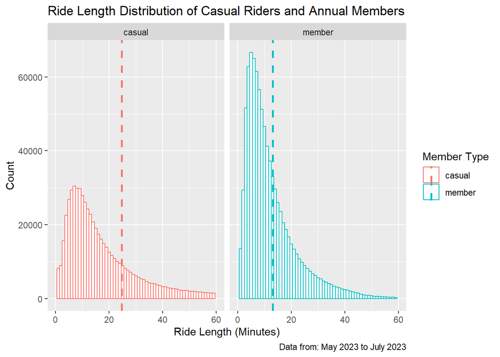

```r
ggplot(data = trips_05_to_07_2023, aes(x = ride_length_min, color = member_casual)) +
  geom_histogram(binwidth = 1, fill = "white") +
  geom_vline(data = mean_mem_cas, aes(xintercept = mean_type, color = member_casual), linetype = "dashed", size = 1) +
  xlim(0, 60) + facet_wrap(~member_casual) +
  labs(title = "Ride Length Distribution of Casual Riders and Annual Members", x = "Ride Length (Minutes)", y = "Count",
       caption = "Data from: May 2023 to July 2023") +
  guides(color = guide_legend(title = "Member Type"))
```

As seen above, generally annual members tend to take shorter rides than casual riders.

## Question 5: what is the average ride length by day of the week?

As seen via table:

```r
mean_ride_day <- trips_05_to_07_2023 %>% group_by(day_of_week) %>%
  summarise(mean_ride_length = mean(ride_length_min))
mean_ride_day
```

```
## # A tibble: 7 × 2
##   day_of_week mean_ride_length
##         <dbl>            <dbl>
## 1           1             21.4
## 2           2             17.2
## 3           3             16.1
## 4           4             15.0
## 5           5             15.6
## 6           6             17.2
## 7           7             21.1
```

As seen via bar chart:

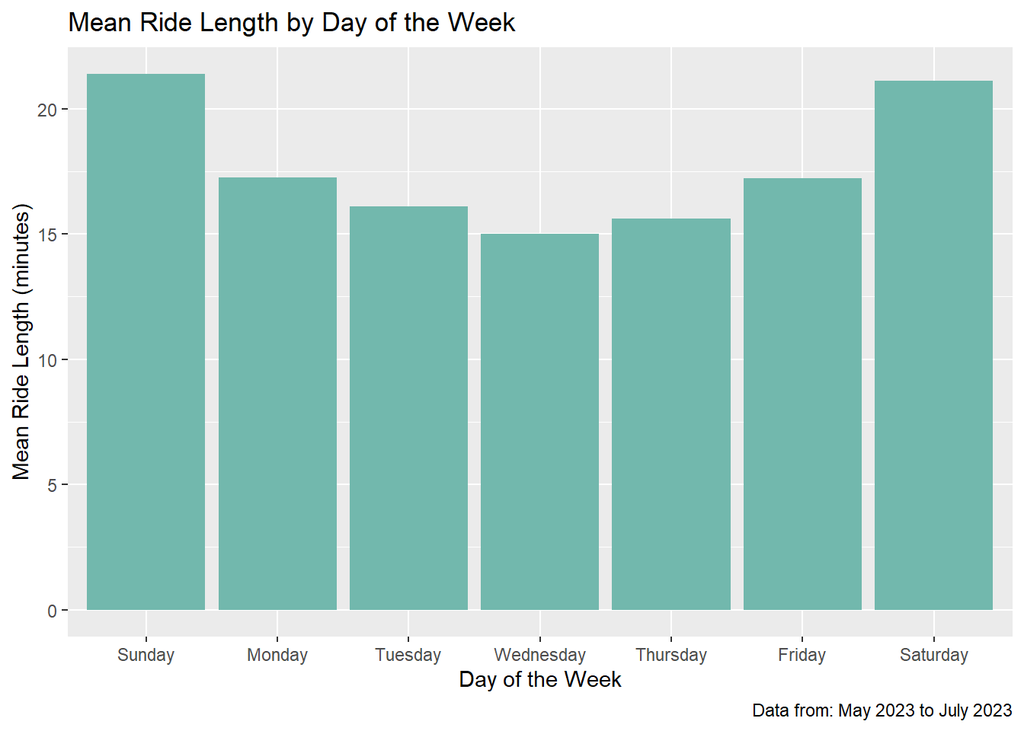

```r
ggplot(data = mean_ride_day, aes(x = factor(day_of_week), y = mean_ride_length)) + geom_bar(stat = "identity", fill='#72B8AD') +
  labs(title = "Mean Ride Length by Day of the Week", x = "Day of the Week", y = "Mean Ride Length (minutes)",
       caption = "Data from: May 2023 to July 2023") +
  scale_x_discrete(labels = week_names)
```